# Data 624 Homework 3

```r
augment(afit) %>%
  features(.resid, ljung_box, lag=10)
```

```
## # A tibble: 1 × 3
##   .model         lb_stat lb_pvalue
##   <chr>            <dbl>     <dbl>
## 1 NAIVE(Exports)    16.4    0.0896
```

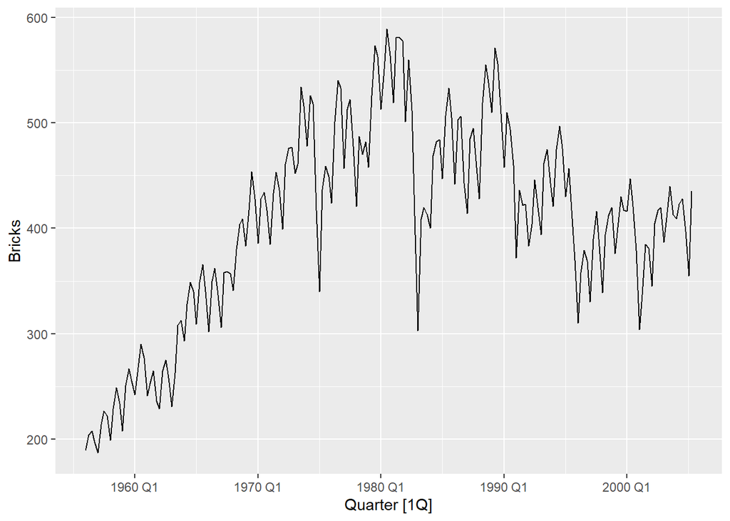

```r
bricks <- aus_production %>%
  filter(!is.na(Bricks)) %>%
  select(Bricks)
autoplot(bricks)
```

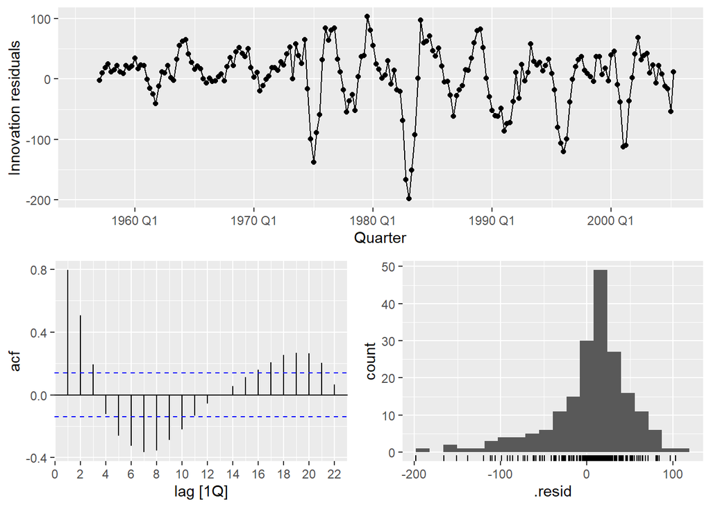

```r
bfit <- bricks %>%
  model(SNAIVE(Bricks))

bfit %>%
  gg_tsresiduals()
```

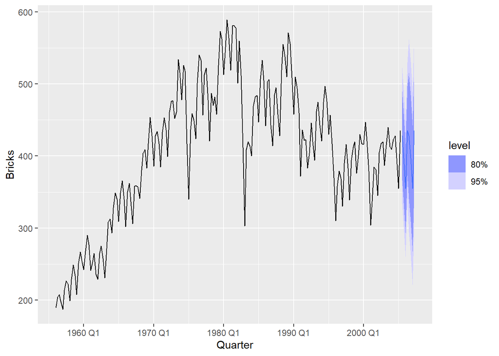

```r
bfit %>%
  forecast() %>%
  autoplot(bricks)
```

```r
augment(bfit) %>%
  features(.resid, ljung_box, lag=8)
```

```
## # A tibble: 1 × 3
##   .model         lb_stat lb_pvalue
##   <chr>            <dbl>     <dbl>
## 1 SNAIVE(Bricks)    274.         0
```

The above visuals show us that the innovation residuals data for bricks from `aus_production` has an obvious pattern with an increase in volatility towards the middle, the majority of the lag segments surpass the boundaries, and its distribution is skewed to the left. In addition, the Q* value is very large and the p-value is very significant which helps us conclude that what is remaining from the forecast is not just white noise and can be improved to take what is remaining into account.

## Exercise 7

For your retail time series (from Exercise 7 in Section 2.10):

```r
set.seed(1)
myseries <- aus_retail %>%
  filter(`Series ID` == sample(aus_retail$`Series ID`,1))
```

Create a training dataset consisting of observations before 2011 using

```r
myseries_train <- myseries %>%
  filter(year(Month) < 2011)
```

Check that your data have been split appropriately by producing the following plot.

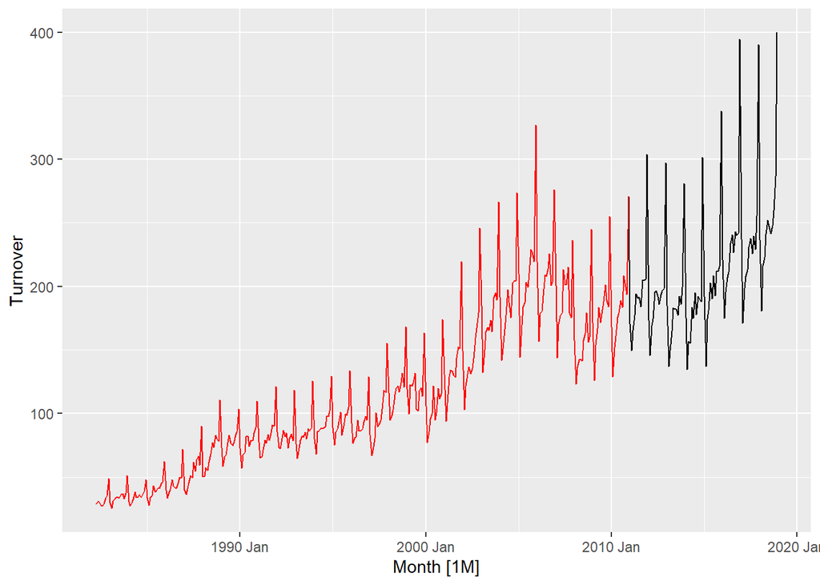

```r
autoplot(myseries, Turnover) +
  autolayer(myseries_train, Turnover, colour = "red")
```

Fit a seasonal naïve model using SNAIVE() applied to your training data (myseries_train).

```r
mfit <- myseries_train %>%
  model(SNAIVE(Turnover))
```

Check the residuals. Do the residuals appear to be uncorrelated and normally distributed?

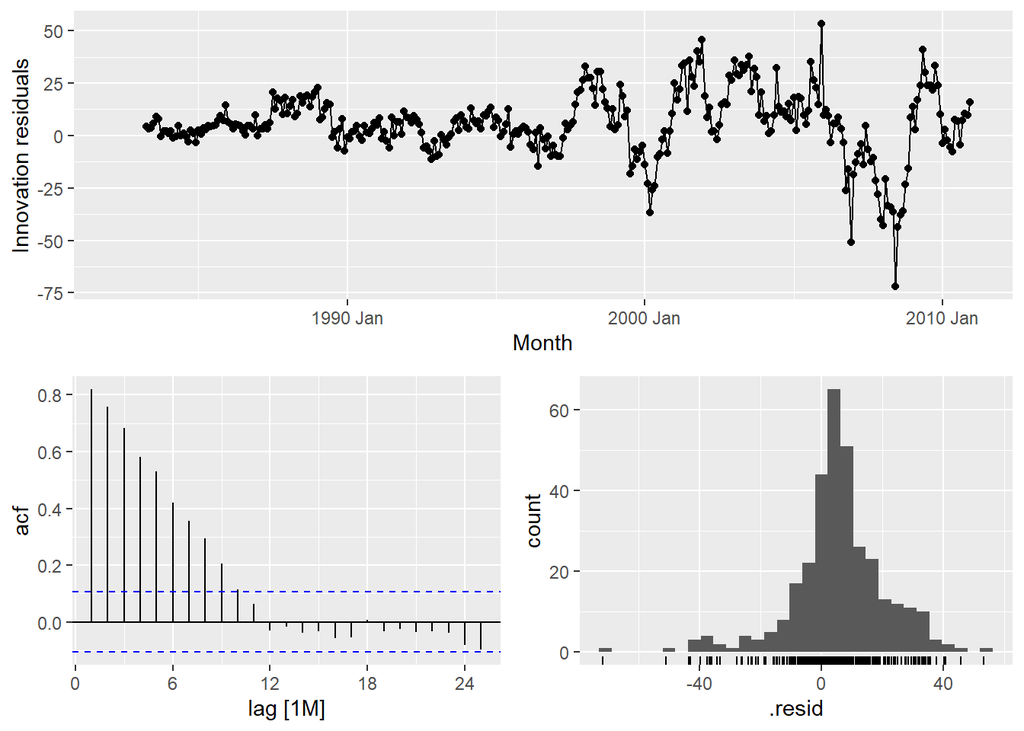

```r
mfit %>%
  gg_tsresiduals()
```

As can be seen above, the residuals do not appear to be uncorrelated due to the innovation residuals chart presenting high dependency after the year 1995, almost half of the segments on the lag chart surpassing the boundaries, and their distribution being narrow and skewed to the left.

Produce forecasts for the test data

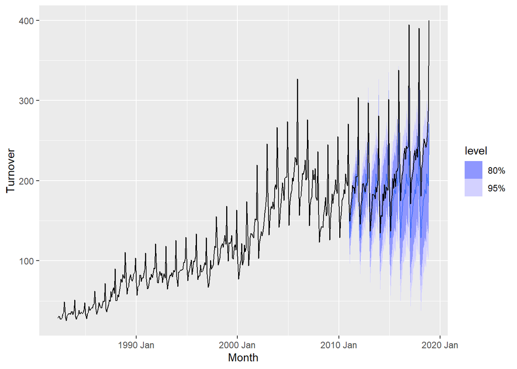

```r
fc <- mfit %>%
  forecast(new_data = anti_join(myseries, myseries_train))
fc %>%
  autoplot(myseries)
```

Compare the accuracy of your forecasts against the actual values.

```r
mfit %>%
  accuracy()
```

```
## # A tibble: 1 × 12
##   State    Industry .model .type    ME  RMSE   MAE   MPE  MAPE  MASE RMSSE  ACF1
##   <chr>    <chr>    <chr>  <chr> <dbl> <dbl> <dbl> <dbl> <dbl> <dbl> <dbl> <dbl>
## 1 Queensl… Clothin… SNAIV… Trai…  5.50  16.5  12.1  5.39  10.6     1     1 0.819
```

```r
fc %>%
  accuracy(myseries)
```

```
## # A tibble: 1 × 12
##   .model    State Industry .type    ME  RMSE   MAE   MPE  MAPE  MASE RMSSE  ACF1
##   <chr>     <chr> <chr>    <chr> <dbl> <dbl> <dbl> <dbl> <dbl> <dbl> <dbl> <dbl>
## 1 SNAIVE(T… Quee… Clothin… Test   26.9  40.2  29.3  11.3  12.6  2.43  2.44 0.752
```

How sensitive are the accuracy measures to the amount of training data used?

The accuracy measures seem to be very sensitive to the amount of training data used. As can be seen in the results above, the measures for the test data are drastically different from the measures for the training data. This is most likely due to the fact that the training data takes into account absolutely everything before what is going to be tested irrespective of any sudden changes or fluctuations that could have taken place towards the end of the data. Meanwhile, the test data, depending on the very last seasonal period in this case, uses the pattern at the very end and repeats it over and over. Given the drastic change in trend between the years 2005-2010, this would lead to the forecast having the errors we see above.